# Sampling bias in radiocarbon dating project: simulation study (no population change) - 5 samples at 100%

Rebecca Wheatley

25 August 2021

## Simulating no change in population growth over time (*without* taphonomic loss)

Data for our analysis is simulated in two steps.

1. Each site in our simulated data set (`no_sites`) has an excess of samples drawn from a distribution that describes the underlying population trend we are aiming to model, bounded between the upper and lower `timeRange` bounds (+-3000 years).
- "no change" simulates a steady population over time (values drawn from a uniform distribution).
- "steady growth" simulates linear population growth (values drawn from an approximately linear distribution).
- "exponential growth" simulates exponential population growth (values drawn from an exponential distribution).
- "growth then decline" simulates an intial steady population growth followed by a population decrease (values drawn from a triangular distribution with the mode at the midpoint between the upper and lower `timeRange` bounds).  
  (see `simulation_study-source.R` for specific implementation of each case)
2. A subset (`no_samples`) of this evidence is then pulled in one of two ways depending on whether we want to simulate taphonomic loss or not:
- if we do not wish to simulate taphonomic loss, samples are pulled from the evidence using a uniform distribution
- if we do wish to simulate taphonomic loss, samples are pulled from the evidence using an exponential distribution with a rate of 0.04/500 (informed by our other study using dynamic occupancy modelling to tease apart population growth and taphonomic loss - more on this later) These samples then form our full data set/s, with and without taphonomic loss.

Set the parameters we want for our simulated data:

```r
timeRange  = c(12000, 200)   ## for Holocene sites
no_sites   = 100             ## the number of sites we want in our simulated data set
no_samples = 5               ## the number of samples we want each site to have
pop_trend  = "no change"     ## the underlying population trend we want to mimic
```

We will run several sampling methods on this data set to investigate different potential biases in radiocarbon dating sampling. These sampling methods are:  
1. **Uniform**. For each site (or some % of sites), choose a number of samples (`sampling_effort`) from a uniform distribution  
2. **Singleton**. For each site (or some % of sites), choose one sample. There are three methods of choosing which sample to use:  
+ the most **ancient** sample  
+ the most **recent** sample  
+ a **random** sample  
3. **Bracketed**. For each site (or some % of sites), choose the most recent and the most ancient sample

There are, therefore, two new parameters for subsampling the baseline data: `percent_sites` and `sampling_effort`. These determine the percent of sites we apply the sampling methods to and the number of samples we want to select if using a uniform sampling method.

```r
percent_sites   = 100  ## the number of sites we want to apply the sampling method across (the remainder will be
                       ## exhaustively sampled)
sampling_effort = 3    ## the number of samples we want to take using the uniform sampling method
nsim            = 20   ## the number of replicates to make when sampling
```

### Summed probability distributions (SPDs)

Plot the resulting summed probability distributions:  
* dashed black line is the SPD for the full data set  
* solid coloured line is the median SPD for the sampled data set  
+ teal = 3 uniformly selected samples from 100% of sites  
+ orange = only the most ancient sample from 100% of sites  
+ blue = only the most recent sample from 100% of sites  
+ pink = one random sample from 100% of sites  
+ green = only the most recent and most ancient sample from 100% of sites (bracketed)  
* ribbon is the 95% confidence interval for the sampled data set (note that when 100% of sites are sampled, some of the subsamples will not have confidence intervals)

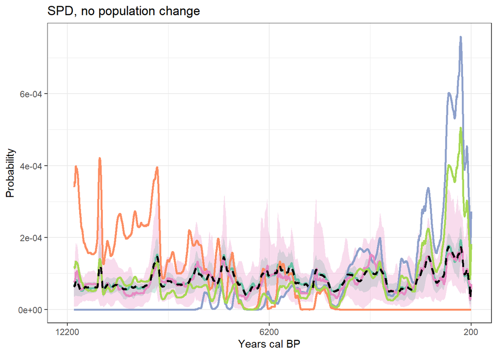

### Frequency distributions of dates within time bins

Plot the resulting frequency distributions:  
* dashed black line is a smoothed spline of the frequency distribution for the full data set  
* solid coloured line is a smoothed spline of the median frequency distribution for the sampled data set  
+ teal = 3 uniformly selected samples from 100% of sites  
+ orange = only the most ancient sample from 100% of sites  
+ blue = only the most recent sample from 100% of sites  
+ pink = one random sample from 100% of sites  
+ green = only the most recent and most ancient sample from 100% of sites (bracketed)  
* ribbon is the 95% confidence interval for the sampled data set (note that when 100% of sites are sampled, some of the subsamples will not have confidence intervals)

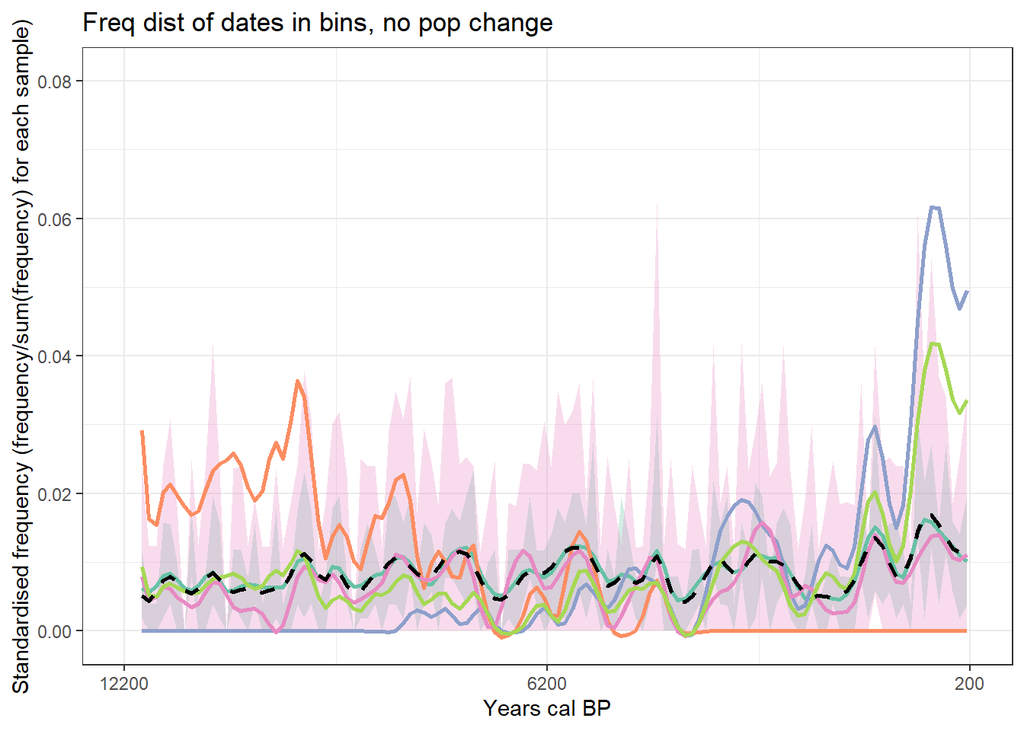

### Frequency distributions of sites with dates within time bins

Plot the resulting frequency distributions:  
* dashed black line is a smoothed spline of the frequency distribution for the full data set  
* solid coloured line is a smoothed spline of the median frequency distribution for the sampled data set  
+ teal = 3 uniformly selected samples from 100% of sites  
+ orange = only the most ancient sample from 100% of sites  
+ blue = only the most recent sample from 100% of sites  
+ pink = one random sample from 100% of sites  
+ green = only the most recent and most ancient sample from 100% of sites (bracketed)  
* ribbon is the 95% confidence interval for the sampled data set (note that when 100% of sites are sampled, some of the subsamples will not have confidence intervals)

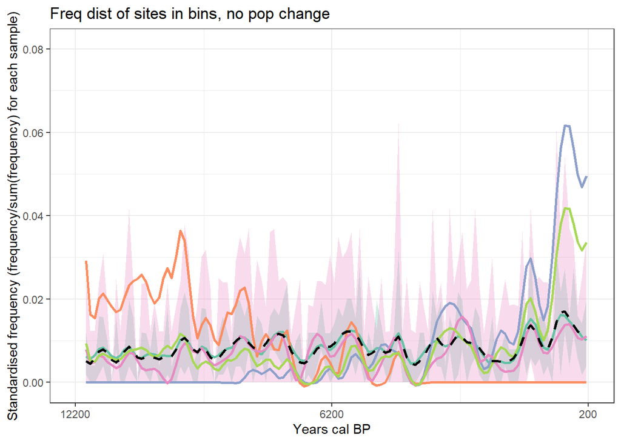

## Simulating no change in population growth over time (*with* taphonomic loss)

Set the parameters we want for our simulated data:

```r
timeRange  = c(12000, 200) ## for Holocene sites
no_sites   = 100           ## the number of sites we want in our simulated data set
no_samples = 5             ## the number of samples we want each site to have
pop_trend  = "no change"   ## the underlying population trend we want to mimic
```

### Summed probability distributions (SPDs)

Plot the resulting summed probability distributions:  
* solid black line is the SPD for the full data set including taphonomic loss  
* solid coloured line is the median SPD for the sampled data set  
+ teal = 3 uniformly selected samples from 100% of sites  
+ orange = only the most ancient sample from 100% of sites  
+ blue = only the most recent sample from 100% of sites  
+ pink = one random sample from 100% of sites  
+ green = only the most recent and most ancient sample from 100% of sites (bracketed)  
* dashed black line is the SPD for the full data set WITHOUT taphonomic loss  
* ribbon is the 95% confidence interval for the sampled data set (note that when 100% of sites are sampled, some of the subsamples will not have confidence intervals)

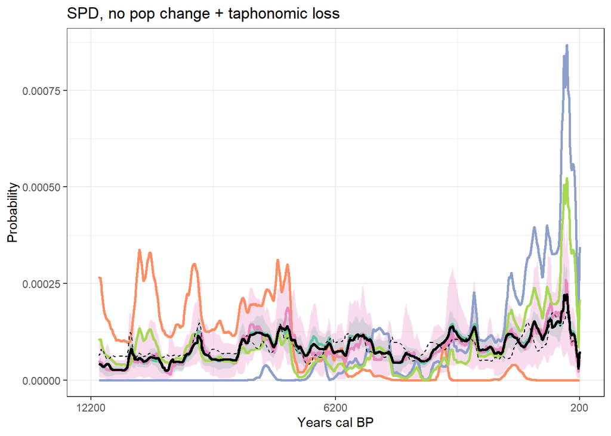

### Frequency distributions of dates within time bins

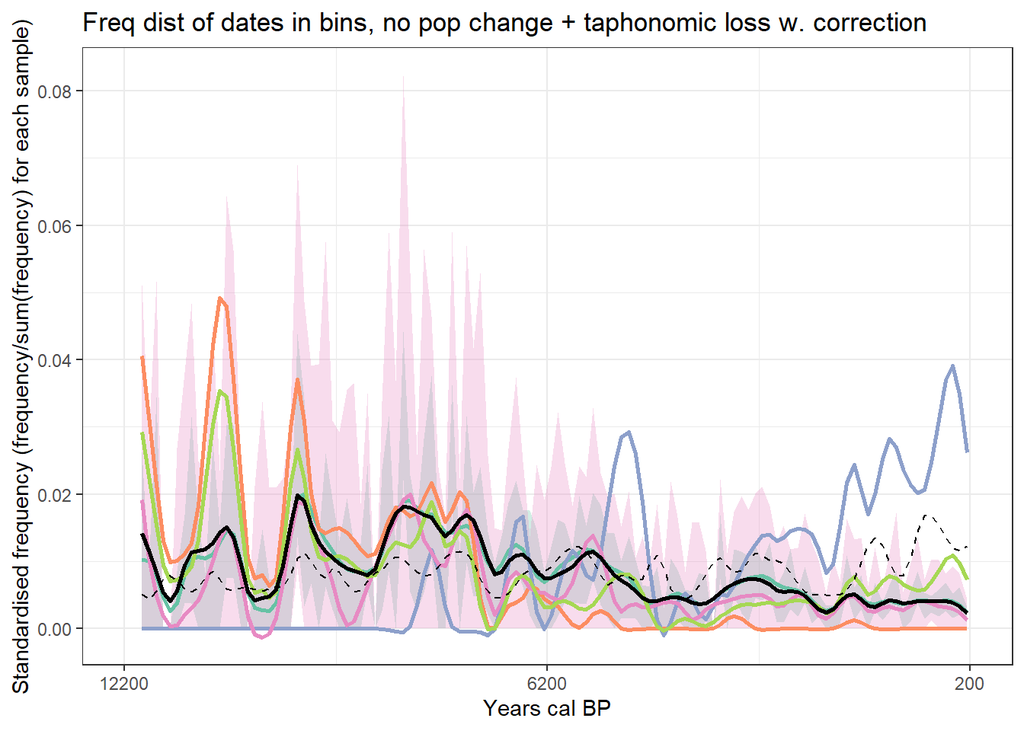

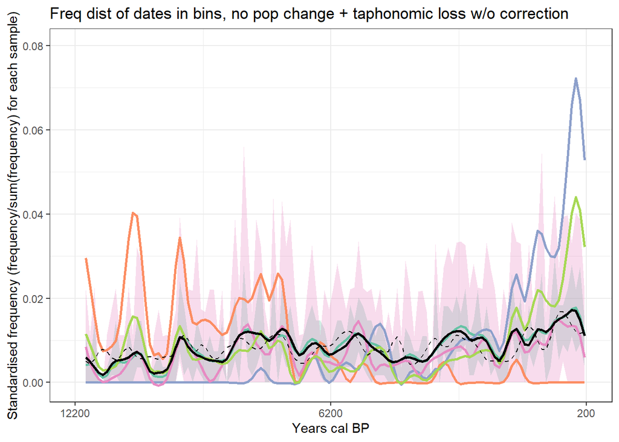

### Frequency distributions of sites with dates within time bins

Plot the resulting frequency distributions:  
* solid black line is a smoothed spline of the frequency distribution for the full data set including taphonomic loss  
* solid coloured line is a smoothed spline of the median frequency distribution for the sampled data set  
+ teal = 3 uniformly selected samples from 100% of sites  
+ orange = only the most ancient sample from 100% of sites  
+ blue = only the most recent sample from 100% of sites  
+ pink = one random sample from 100% of sites  
+ green = only the most recent and most ancient sample from 100% of sites (bracketed)  
* dashed black line is a smoothed spline of the frequency distribution of the full data set WITHOUT taphonomic loss  
* ribbon is the 95% confidence interval for the sampled data set

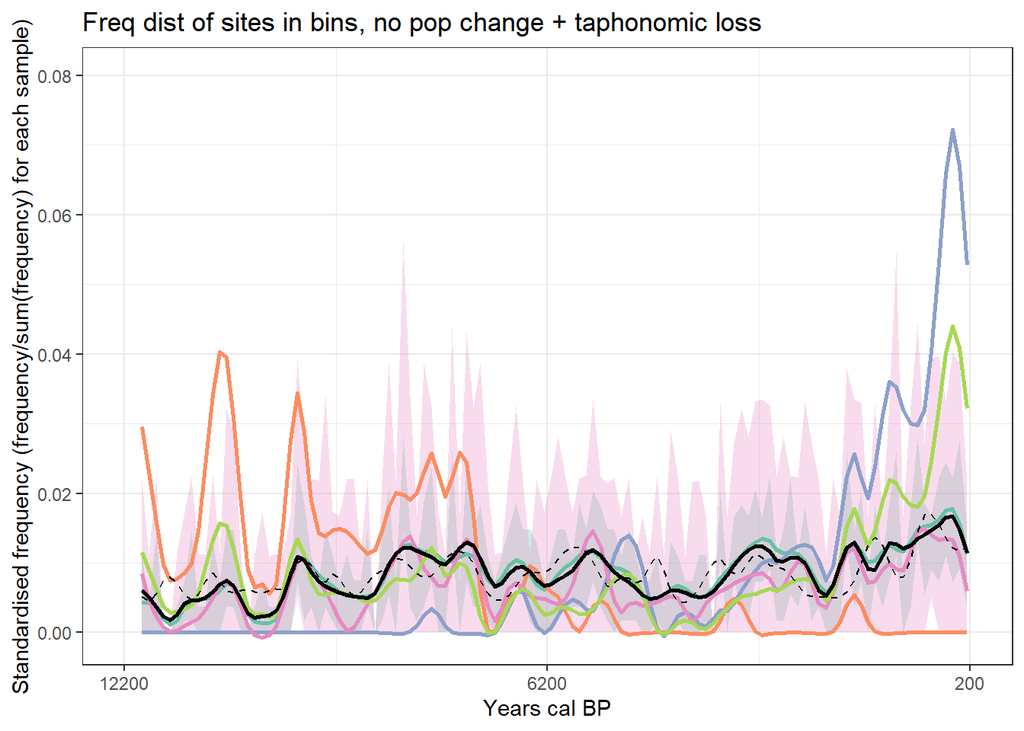